# IODS course project

## 1.2 Summary of the Variables

The `summary` function reveals there is a lot of variance in many of the variables:

```r
summary(Boston)
```

```
##       crim                zn             indus            chas
##  Min.   : 0.00632   Min.   :  0.00   Min.   : 0.46   Min.   :0.00000
##  1st Qu.: 0.08205   1st Qu.:  0.00   1st Qu.: 5.19   1st Qu.:0.00000
##  Median : 0.25651   Median :  0.00   Median : 9.69   Median :0.00000
##  Mean   : 3.61352   Mean   : 11.36   Mean   :11.14   Mean   :0.06917
##  3rd Qu.: 3.67708   3rd Qu.: 12.50   3rd Qu.:18.10   3rd Qu.:0.00000
##  Max.   :88.97620   Max.   :100.00   Max.   :27.74   Max.   :1.00000
##       nox               rm             age              dis
##  Min.   :0.3850   Min.   :3.561   Min.   :  2.90   Min.   : 1.130
##  1st Qu.:0.4490   1st Qu.:5.886   1st Qu.: 45.02   1st Qu.: 2.100
##  Median :0.5380   Median :6.208   Median : 77.50   Median : 3.207
##  Mean   :0.5547   Mean   :6.285   Mean   : 68.57   Mean   : 3.795
##  3rd Qu.:0.6240   3rd Qu.:6.623   3rd Qu.: 94.08   3rd Qu.: 5.188
##  Max.   :0.8710   Max.   :8.780   Max.   :100.00   Max.   :12.127
##       rad              tax           ptratio          black
##  Min.   : 1.000   Min.   :187.0   Min.   :12.60   Min.   :  0.32
##  1st Qu.: 4.000   1st Qu.:279.0   1st Qu.:17.40   1st Qu.:375.38
##  Median : 5.000   Median :330.0   Median :19.05   Median :391.44
##  Mean   : 9.549   Mean   :408.2   Mean   :18.46   Mean   :356.67
##  3rd Qu.:24.000   3rd Qu.:666.0   3rd Qu.:20.20   3rd Qu.:396.23
##  Max.   :24.000   Max.   :711.0   Max.   :22.00   Max.   :396.90
##      lstat            medv
##  Min.   : 1.73   Min.   : 5.00
##  1st Qu.: 6.95   1st Qu.:17.02
##  Median :11.36   Median :21.20
##  Mean   :12.65   Mean   :22.53
##  3rd Qu.:16.95   3rd Qu.:25.00
##  Max.   :37.97   Max.   :50.00
```

For example, the crime rate per capita differs between 0.006 and 88.976. The zoning (zn) indicates the proportion of residential land zoned for lots over 25,000 sq.ft. A difference between 0-100 means that some areas/towns are zoned to be entirely residential.  
The chas variable is described as a “Charles River dummy variable (= 1 if tract bounds river; 0 otherwise)” in the metadata. Here it is deviant because it operates on a binary 1/0 output (though loading the dataset treats it as an integer class). I omit it from the dataset.

```r
b1 <- Boston[-4]
```

## 1.3 Correlation Matrix Plot

A correlation matrix plot is an easier to read plot. Here, the dark blue circles indicate strong positive correlation and dark red circles indicate strong negative correlations. For example, median value of owner-occupied homes (medv) correlates negatively with the percent of lower status (socio-economic status) population (lstat).

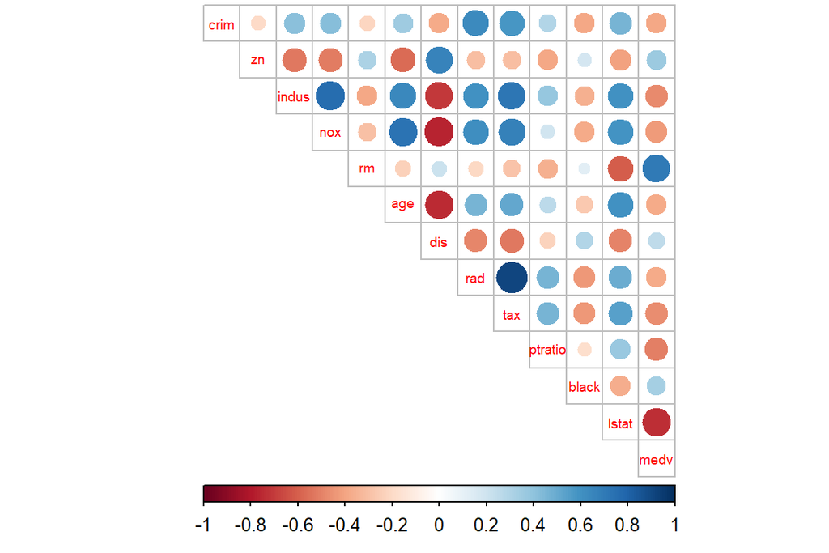

```r
cor_matrix<-cor(b1) %>% round(digits = 2)

corrplot(cor_matrix, method="circle", type = "upper", cl.pos = "b", tl.pos = "d", tl.cex = 0.6)
```

## 2 Creating a Dataframe

### 2.1 Scaling Data

To create a standardised dataframe the values need to be scaled. This is done by subtracting columns means from the columns and dividing the difference with standard deviation. In R it can be done with the `scale()` function. *(Note to self, only works on numerical values)* The `class` function can check the class of the new data. Here the class is a matrix, which I change to a dataframe.

```r
b1_scaled <- scale(b1)

class(b1_scaled)
```

```
## [1] "matrix" "array"
```

```r
b1_scaled <- as.data.frame(b1_scaled)
```

**A summary of the new dataframe**:

```r
summary(b1_scaled)
```

```
##       crim                 zn               indus              nox
##  Min.   :-0.419367   Min.   :-0.48724   Min.   :-1.5563   Min.   :-1.4644
##  1st Qu.:-0.410563   1st Qu.:-0.48724   1st Qu.:-0.8668   1st Qu.:-0.9121
##  Median :-0.390280   Median :-0.48724   Median :-0.2109   Median :-0.1441
##  Mean   : 0.000000   Mean   : 0.00000   Mean   : 0.0000   Mean   : 0.0000
##  3rd Qu.: 0.007389   3rd Qu.: 0.04872   3rd Qu.: 1.0150   3rd Qu.: 0.5981
##  Max.   : 9.924110   Max.   : 3.80047   Max.   : 2.4202   Max.   : 2.7296
##        rm               age               dis               rad
##  Min.   :-3.8764   Min.   :-2.3331   Min.   :-1.2658   Min.   :-0.9819
##  1st Qu.:-0.5681   1st Qu.:-0.8366   1st Qu.:-0.8049   1st Qu.:-0.6373
##  Median :-0.1084   Median : 0.3171   Median :-0.2790   Median :-0.5225
##  Mean   : 0.0000   Mean   : 0.0000   Mean   : 0.0000   Mean   : 0.0000
##  3rd Qu.: 0.4823   3rd Qu.: 0.9059   3rd Qu.: 0.6617   3rd Qu.: 1.6596
##  Max.   : 3.5515   Max.   : 1.1164   Max.   : 3.9566   Max.   : 1.6596
##       tax             ptratio            black             lstat
##  Min.   :-1.3127   Min.   :-2.7047   Min.   :-3.9033   Min.   :-1.5296
##  1st Qu.:-0.7668   1st Qu.:-0.4876   1st Qu.: 0.2049   1st Qu.:-0.7986
##  Median :-0.4642   Median : 0.2746   Median : 0.3808   Median :-0.1811
##  Mean   : 0.0000   Mean   : 0.0000   Mean   : 0.0000   Mean   : 0.0000
##  3rd Qu.: 1.5294   3rd Qu.: 0.8058   3rd Qu.: 0.4332   3rd Qu.: 0.6024
##  Max.   : 1.7964   Max.   : 1.6372   Max.   : 0.4406   Max.   : 3.5453
##       medv
##  Min.   :-1.9063
##  1st Qu.:-0.5989
##  Median :-0.1449
##  Mean   : 0.0000
##  3rd Qu.: 0.2683
##  Max.   : 2.9865
```

The summary shows that the variables have now been scaled so that the mean is 0 for each variable.

### 2.2 Crime Rate as a Categorical Variable

For the purposes of the assignment I create a new four category variable of the crime rate (crim). The observations are assigned in categories based on quantile break points.  
A quantile vector can be created with the `quantile` function that produces the 0%,25%,50%, 75%, and 100% of a variable. A character vector is created that contains the names that are desired for the four categories.  
A new factor with 4 levels is created with the `cut()` function. The `breaks =` argument specifies the breaking points and `label =` argument the desired names for the categories. I create a new dataframe from omitting the old crime rate variable and replacing it with the new 4-category variable. Looking at the `str()` of the dataset reveals the new category to be a factor class with 4 levels.

```r
qvec <- quantile(b1_scaled$crim)
nvec <- c("low", "low_med", "med_high", "high")

crime <- cut(b1_scaled$crim, breaks = qvec, include.lowest = TRUE, label = nvec)

b2 <- b1_scaled %>% dplyr::select(-crim)
b2 <- data.frame(b2, crime)
str(b2)
```

```
## 'data.frame':    506 obs. of  13 variables:
##  $ zn     : num  0.285 -0.487 -0.487 -0.487 -0.487 ...
##  $ indus  : num  -1.287 -0.593 -0.593 -1.306 -1.306 ...
##  $ nox    : num  -0.144 -0.74 -0.74 -0.834 -0.834 ...
##  $ rm     : num  0.413 0.194 1.281 1.015 1.227 ...
##  $ age    : num  -0.12 0.367 -0.266 -0.809 -0.511 ...
##  $ dis    : num  0.14 0.557 0.557 1.077 1.077 ...
##  $ rad    : num  -0.982 -0.867 -0.867 -0.752 -0.752 ...
##  $ tax    : num  -0.666 -0.986 -0.986 -1.105 -1.105 ...
##  $ ptratio: num  -1.458 -0.303 -0.303 0.113 0.113 ...
##  $ black  : num  0.441 0.441 0.396 0.416 0.441 ...
##  $ lstat  : num  -1.074 -0.492 -1.208 -1.36 -1.025 ...
##  $ medv   : num  0.16 -0.101 1.323 1.182 1.486 ...
##  $ crime  : Factor w/ 4 levels "low","low_med",..: 1 1 1 1 1 1 2 2 2 2 ...
```

### 2.3 Creating Train and Test sets

In this section the dataframe created in the past sections is divided randomly into training (80% of the dataframe) and testing (20% of the dataframe) datasets. This can be done with the `sample()` function. The sample size is specified with the argument `size =`. For the size argument I create the value **n** which is the number of observations (rows) * 0.8 in the b2 dataframe. Train and test sets are created by selecting the rows that are saved in `ind` (train set), and then subtracting the rows in `ind` to create the test set. The train set now has 404 observations and the test set 102 observations.

```r
n <- nrow(b2)

ind <- sample(n,  size = n * 0.8)

train <- b2[ind,]

test <- b2[-ind,]

dim(train)
```

```
## [1] 404  13
```

```r
dim(test)
```

```
## [1] 102  13
```

In section 3.2 these sets will be used for prediction. A new value needs to be created for saving correct crime classes in the test dataframe, because these will be removed from the dataframe. (*Not to Self, here `dplyr::select` must be specified because of overlaps in the MASS package.*)

```r
correct_classes <- test$crime


test <- dplyr::select(test, -crime)
```

## 3 Linear Discriminant Analysis

### 3.1 Creating an LDA Model

Linear Discriminant Analysis is a classification method that can be used to find variables that discriminate categorical classes, and predict the classes of new data. In this section LDA is performed on the categorical crime rate variable created in the previous sections.  
An LDA formula is created with the `lda()` function. It is specified with a target variable with the formula `lda(target ~`. For the purposes of this task it will be predicted by all the other variables in the train dataframe. The results for the LDA model can be viewed by printing and plotting. The `lda.arrows` function that is created to complement the plot is magic as far as I’m concerned.

```r
# linear discriminant analysis
lda.fit <- lda(crime ~ ., data = train)


print(lda.fit)
```

```
## Call:
## lda(crime ~ ., data = train)
##
## Prior probabilities of groups:
##       low   low_med  med_high      high
## 0.2524752 0.2500000 0.2425743 0.2549505
##
## Group means:
##                   zn      indus        nox         rm        age        dis
## low       0.98928865 -0.9098192 -0.8668705  0.4587232 -0.8648488  0.8609063
## low_med  -0.08181776 -0.3276318 -0.5754020 -0.1185958 -0.3184854  0.3856510
## med_high -0.38135991  0.1739151  0.4283972  0.1386192  0.4242603 -0.4030735
## high     -0.48724019  1.0170891  1.0664417 -0.4302132  0.8234257 -0.8608474
##                 rad        tax    ptratio      black       lstat         medv
## low      -0.6925025 -0.7292971 -0.4114781  0.3847562 -0.76805527  0.534006278
## low_med  -0.5395408 -0.4867719 -0.1020257  0.3158043 -0.12866516 -0.004428254
## med_high -0.4252163 -0.3308325 -0.3485137  0.0492612  0.03539433  0.186155514
## high      1.6384176  1.5142626  0.7811136 -0.7724384  0.92536688 -0.633250250
##
## Coefficients of linear discriminants:
##                  LD1         LD2          LD3
## zn       0.065762501  0.66419096 -1.014619918
## indus    0.003283495 -0.31116160  0.368864763
## nox      0.361125399 -0.69334230 -1.391259423
## rm      -0.111725227 -0.12868560 -0.174702068
## age      0.201926215 -0.28944589 -0.009686939
## dis     -0.074081647 -0.13268777  0.273691145
## rad      3.308784907  0.78967631  0.101814765
## tax      0.093228730  0.19586852  0.428070665
## ptratio  0.111245437  0.09427180 -0.424716092
## black   -0.111207975  0.04243336  0.172878723
## lstat    0.196648481 -0.19104946  0.277498151
## medv     0.165276205 -0.31453330 -0.218924819
##
## Proportion of trace:
##    LD1    LD2    LD3
## 0.9510 0.0361 0.0129
```

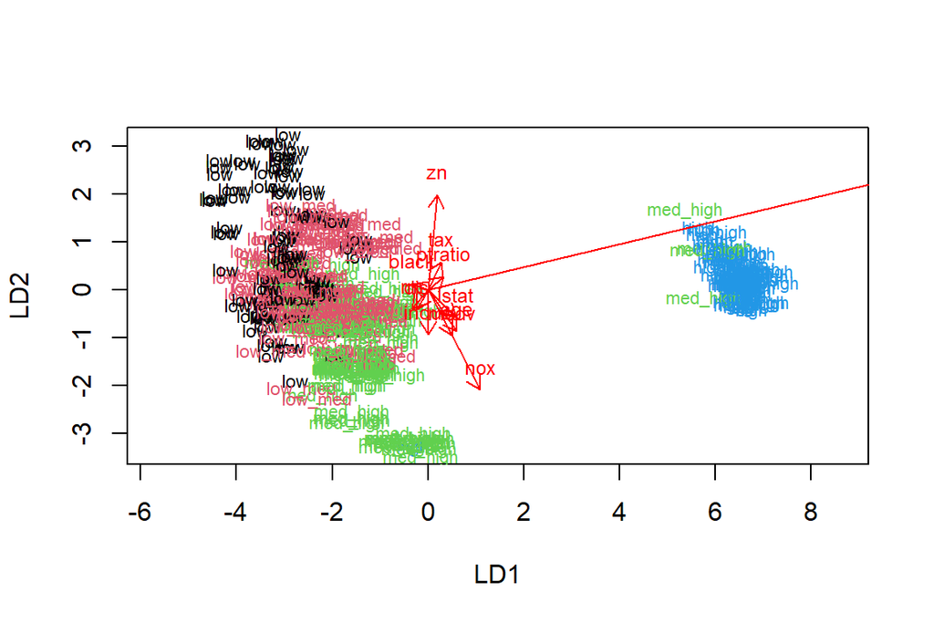

```r
# the function for lda biplot arrows (DataCamp exercise)
lda.arrows <- function(x, myscale = 1, arrow_heads = 0.1, color = "red", tex = 0.75, choices = c(1,2)){
  heads <- coef(x)
  arrows(x0 = 0, y0 = 0,
         x1 = myscale * heads[,choices[1]],
         y1 = myscale * heads[,choices[2]], col=color, length = arrow_heads)
  text(myscale * heads[,choices], labels = row.names(heads),
       cex = tex, col=color, pos=3)
}

# target classes as numeric
classes <- as.numeric(train$crime)

# plot the lda results
plot(lda.fit, dimen = 2, col = classes, pch = classes)
lda.arrows(lda.fit, myscale = 3)
```

The LD1 axis accounts for the most variation between the categories. It’s coefficients of linear discriminants are displayed in the `print()` of the LDA model. Here, especially the **rad** (index of accessibility to radial highways) variable stands out as a strong coefficient for the high crime rate category. This is distinctly visible in the plot on the LD1 axis (the red line racing out of the plot is the rad variable), resulting in a separated cluster of mostly high crime rates (with some med_high).  
The LD2 axis accounts for the second most variation between the categories. Here, the **zn** (proportion of residential land zoned for lots over 25,000 sq.ft.) and **nox** (nitrogen oxides concentration) along with the **rad** are the strongest discriminatory coefficients. The LD2 axis in the biplot shows some separation between the low, low_mid and mid_high categories though this separation is also considerably overlapping. If we are to ask what the data tells us, then we are probably looking at infrastructural and socio-environmental variables that separate between higher crime-rate urban areas with higher pollution (and guaranteed access to radial highways) and the sub-urb *sprawl of white picket fenced green lawns, where domestic violence goes unreported, and neighbours greet each other with daggers in their smiles, sizzling with repressed anger that they STILL have not returned the leaf blower they borrowed months ago, the thief! One day I’ll..! But my mortgage. Oh the horror, too committed to my middle-class mediocrity to act on my violent urges.* Uh. Yeah the data does not *exactly* state that. Onwards!

## 3.2 Performing Prediction

The LDA model created in the previous section from the training dataset can be used to predict the testing dataset. This is done with the `predict()` function. The `newdata =` argument specifies the dataset to predict on. The test dataframe, in this case.

```r
# predict classes with test data
lda.pred <- predict(lda.fit, newdata = test)

# cross tabulate the results
table(correct = correct_classes, predicted = lda.pred$class)
```

```
##           predicted
## correct    low low_med med_high high
##   low       15       9        1    0
##   low_med    2      19        4    0
##   med_high   1       8       17    2
##   high       0       0        0   24
```

## 4 K-Means Clustering

### 4.1 Calculating Distance

To calculate distance use the `dist()` function. A summary shows the mean distance for all variables to be 4.91, but with quite a bit of variation in the Min (0.1343) and Max (14.3970) values.

```r
data("Boston")
b3 <- scale(Boston)
b3 <- as.data.frame(b3)
summary(b3)
```

```
##       crim                 zn               indus              chas
##  Min.   :-0.419367   Min.   :-0.48724   Min.   :-1.5563   Min.   :-0.2723
##  1st Qu.:-0.410563   1st Qu.:-0.48724   1st Qu.:-0.8668   1st Qu.:-0.2723
##  Median :-0.390280   Median :-0.48724   Median :-0.2109   Median :-0.2723
##  Mean   : 0.000000   Mean   : 0.00000   Mean   : 0.0000   Mean   : 0.0000
##  3rd Qu.: 0.007389   3rd Qu.: 0.04872   3rd Qu.: 1.0150   3rd Qu.:-0.2723
##  Max.   : 9.924110   Max.   : 3.80047   Max.   : 2.4202   Max.   : 3.6648
##       nox                rm               age               dis
##  Min.   :-1.4644   Min.   :-3.8764   Min.   :-2.3331   Min.   :-1.2658
##  1st Qu.:-0.9121   1st Qu.:-0.5681   1st Qu.:-0.8366   1st Qu.:-0.8049
##  Median :-0.1441   Median :-0.1084   Median : 0.3171   Median :-0.2790
##  Mean   : 0.0000   Mean   : 0.0000   Mean   : 0.0000   Mean   : 0.0000
##  3rd Qu.: 0.5981   3rd Qu.: 0.4823   3rd Qu.: 0.9059   3rd Qu.: 0.6617
##  Max.   : 2.7296   Max.   : 3.5515   Max.   : 1.1164   Max.   : 3.9566
##       rad               tax             ptratio            black
##  Min.   :-0.9819   Min.   :-1.3127   Min.   :-2.7047   Min.   :-3.9033
##  1st Qu.:-0.6373   1st Qu.:-0.7668   1st Qu.:-0.4876   1st Qu.: 0.2049
##  Median :-0.5225   Median :-0.4642   Median : 0.2746   Median : 0.3808
##  Mean   : 0.0000   Mean   : 0.0000   Mean   : 0.0000   Mean   : 0.0000
##  3rd Qu.: 1.6596   3rd Qu.: 1.5294   3rd Qu.: 0.8058   3rd Qu.: 0.4332
##  Max.   : 1.6596   Max.   : 1.7964   Max.   : 1.6372   Max.   : 0.4406
##      lstat              medv
##  Min.   :-1.5296   Min.   :-1.9063
##  1st Qu.:-0.7986   1st Qu.:-0.5989
##  Median :-0.1811   Median :-0.1449
##  Mean   : 0.0000   Mean   : 0.0000
##  3rd Qu.: 0.6024   3rd Qu.: 0.2683
##  Max.   : 3.5453   Max.   : 2.9865
```

```r
euclidean <- dist(b3)
summary(euclidean)
```

```
##    Min. 1st Qu.  Median    Mean 3rd Qu.    Max.
##  0.1343  3.4625  4.8241  4.9111  6.1863 14.3970
```